# Homework 3

Adada

October 26, 2014

### 1. Data Download and Data Parse

We download the parking violation data set, extract the variables of our interest, rename the column name and change the format of the date. Next, we remove the invalid violation records whose precinct numbers are beyond the scope. We extract and capitalize the address, and replace the address with the alternative terms for the sake of matching these information in the database of Pluto. All the possible terms are found manually. Finally, we replace the original address with the alternative one.

```r
check_packages = function(names)
{
  for(name in names)
  {
    if (!(name %in% installed.packages()))
      install.packages(name, repos="http://cran.us.r-project.org")

    library(name, character.only=TRUE)
  }
}
check_packages(c("data.table","lubridate","dplyr","sp","rgdal","maptools","rgeos","raster","stringr","rjson","reshape","e1071","mvoutlier"))
```

```
##
##  '/tmp/Rtmp4YZYMb/downloaded_packages'
```

```r
park = fread("/home/vis/cr173/Sta523/data/parking/NYParkingViolations.csv",sep=",")
park = as.data.frame(park)
```

```r
p = park[c("Violation Precinct",
           "House Number","Street Name")]
colnames(p) = c("violation.precinct","house.number","street.name")

p=filter(p, violation.precinct>0,violation.precinct<=34)

a = p[,3]
a = toupper(a)
d = c("C/O\\ ","S/E\\ ","N/W\\ ","S/S/O\\ ","S/EC/O\\ ","N/O\\ ","S/S\\ ","N/E\\ ","N/S\\ ","S/W\\ "," N/E/C\\ ", "C/OF\\ ","N/WC/O\\ ", "E/S\\ ", "N/S\\ ","W/S\\ ","\\ EAST","\\ WEST","\\ NORTH","\\ SOUTH","^E\\ ","^W\\ ","^N\\ ","^S\\ ","1ST\\ ", "2ND\\ ","3RD\\ "," AVENUE\\ ","\\ AV","\\ VE","\\ AVENUE","AVE\\ ", "\\ AVE", "\\ STREET","\\ STR","\\ ST","TH\\ ","\\ DRIVE","\\ DR","\\ RD", "\\ PK\\ W","\\ PKWY", "\\ PLAZA","\\ PL","\\ PRAZA", "\\ CONC","\\ TER","\\ CP","STREET\\ S","STREET\\ N","STREET\\ W","STREET\\ E")
e = c("","","","","","","","","","","","","","","",""," E", " W", " N"," S","EAST ","WEST ","NORTH ","SOUTH ","1 ","2 ","3 "," AVE", " AVE", "AVE "," AVE","AVENUE ", " AVENUE", " ST", " ST"," STREET"," "," DR"," DRIVE"," ROAD", " PARKWAY", " PARKWAY"," PRAZA"," PLACE", " PLAZA", " CONCOURSE", " TERRACE"," CAMP","STREET SOUTH","STREET NORTH","STREET WEST","STREET EAST")

for (i in 1:length(d))
{
  a=str_replace(a,d[i],e[i])
}
a = as.data.frame(a)
colnames(a) = "street.name"
p = cbind(p[,-3],a)
```

[output not shown]

[output not shown]

```r
pt = gCentroid(pl,byid=TRUE)
tax = cbind(data.frame(pt@coords), as.character(pl@data$Address))
names(tax)[3] = "addr"

z = inner_join(p, tax)
data.m = melt(z, id=c(1,3,4), measure=c(2))
data.c = cast(data.m, addr ~ variable, mean)
colnames(data.c) = c("addr","mean.precinct")
z = inner_join(z, data.c)
```

```r
z$diff = abs(z$violation.precinct-z$mean.precinct)
z = filter(z,diff<=0.5)
z = unique(z)

z = z[2:4]
z$violation.precinct = as.integer(as.character(z$violation.precinct))
z = na.omit(z)
precinctlist = c(1,5,6,7,9,10,13,17,19,14,18,20,23,24,25,26,28,30,32,33,34)
z = z[is.element(z$violation.precinct,precinctlist),]

pm = matrix(nrow=0,ncol=nrow(z))
for (i in 1:length(precinctlist)){
  pi = precinctlist[i]
  f = filter(z, violation.precinct==pi)
  nf = floor(nrow(f)*0.99)
  xmean = mean(f[,2])
  ymean = mean(f[,3])
  f$distance = (f[,2]-xmean)^2+(f[,3]-ymean)^2
  f = arrange(f,distance)%>%slice(1:nf)
  pm = rbind(pm,f[,1:3])
}
z = pm
z=filter(z, x<= -73.968520 | x>=-73.962834 | y<=40.781801 | y>=40.785668)
#plot(z$x,z$y,col=z$violation.precinct)
```

### 3. Preparation for SVM Analysis

We assign an index to each row of the cleased database, convert it into spatial points and then generate polygons of precincts before SVM analysis by using gConvexhull. We create a database of the index for each polygon.

```r
o = order(z$violation.precinct)
pts = as.matrix(z[o, c("x","y")])
rownames(pts) = as.numeric(z$violation.precinct[o])
#head(pts)

spt = SpatialPoints(pts)
Spoly = gConvexHull(spt,byid=TRUE)
precinct = sapply(Spoly@polygons, function(x) x@ID)
data = data.frame(precinct = as.integer(sapply(Spoly@polygons, function(x) x@ID), stringsAsFactors=FALSE))
rownames(data)=precinct
```

### 4. SVM Analysis, Drawing Polygons and Creating Json File

We use SVM to predict which precinct each point belongs to. Also, by using the package of “raster”, we create a grid over Manhanttan island. Selecting the cells that each precinct has, combining the cells, and converting them into spatial polygons data frame, we generate the database of the polyons for each precinct after SVM analysis. We also draw the precinct polygons in R. Our last job is to create Json file from the spatial polygons data frame.

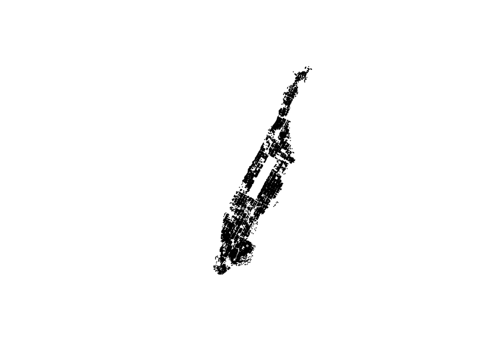

```r
k = svm(as.factor(violation.precinct)~.,data=z,cross=10)
r = rasterize(spt, raster(ncols=500,nrows=1000,ext=extent(bbox(spt))))

cells = which(!is.na(r[]))
crds = xyFromCell(r,cells)

pre = predict(k,crds)

r[cells] = as.numeric(as.character(pre))

V.P = sort(unique(z$violation.precinct))
l = list()
for(i in seq_along(V.P))
{
  l[[i]] = rasterToPolygons(r, function(x) x == V.P[i],dissolve=TRUE)
  l[[i]]@polygons[[1]]@ID = as.character(V.P[i])
  rownames(l[[i]]@data) = V.P[i]
  colnames(l[[i]]@data) = "violation.precinct"
}

pd = do.call(rbind, l)
plot(pd)
```

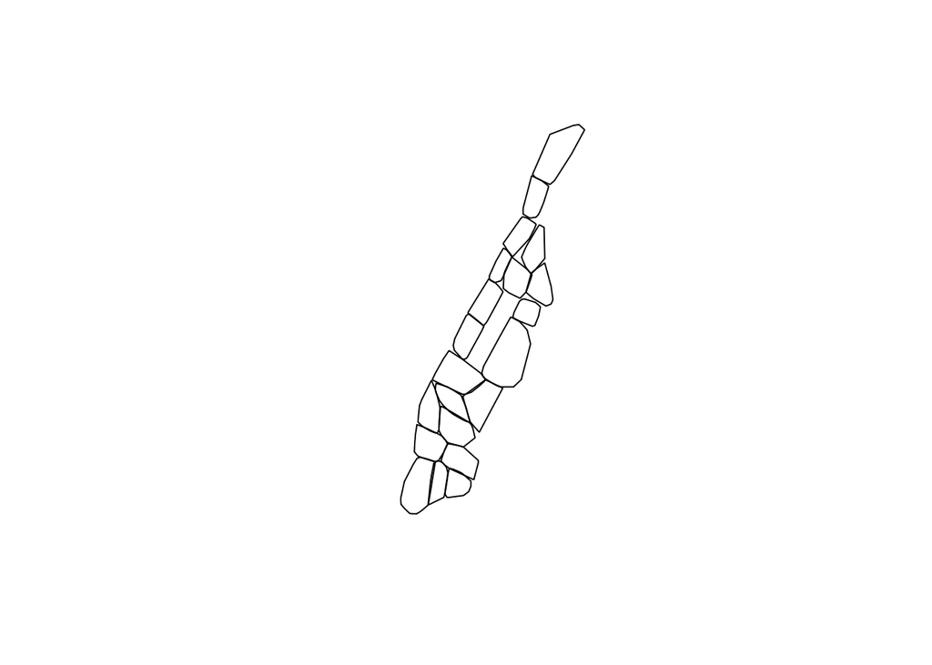

```r
pf = gConvexHull(pd,byid=TRUE)
plot(pf)
```

```r
s = SpatialPolygonsDataFrame(pf,data=data)

writeGeoJSON = function(sp, file)
{
  stopifnot(class(sp) == "SpatialPolygonsDataFrame")
  stopifnot(!missing(sp))

  sp = createSPComment(sp)

  poly_json = function(x)
  {
    owners = as.integer(str_split(comment(x)," ")[[1]])

    paste("[",
          paste(
            sapply(which(owners == 0), function(i)
            {
              res = "[ ["

              res = paste(res, paste("[", apply(x@Polygons[[i]]@coords, 1, paste, collapse=", "), "]", collapse=", "))

              for (j in which(i %in% owners))
              {
                res = paste(res, "], [")

                res = paste(res, paste("[", apply(x@Polygons[[j]]@coords, 1, paste, collapse=", "), "]", collapse=", "))
              }

              res = paste(res, "] ]")
            }),
            collapse = ", "
          ),
          "]")
  }
  qt = function(x) paste0('"',x,'"')

  res = paste('{',
              '"type": "FeatureCollection",',
              '"features": [',
              paste(
                sapply(1:nrow(sp), function(i)
                {
                  paste('{ "type": "Feature",',
                        '"properties": { ',
                        paste(qt(names(sp)), sp@data[i,], sep=": ", collapse=", "),
                        ' },',
                        '"geometry": {',
                        '    "type": "MultiPolygon",',
                        '    "coordinates": ',
                        poly_json(sp@polygons[[i]]),
                        '} }',
                        sep="\n")
                }),
                collapse=",\n"
              ),
              '] }')

  cat(length(res),"\n\n")

  write(res, file = file)
}
writeGeoJSON(s, "./precinct.json")
```

```
## 1
```